# Binary Classification: Scikit-Learn

### 3.2 Decision Tree Classification

#### 3.2.1 Fitting Decision Tree Model

```python
from sklearn.tree import DecisionTreeClassifier

dtc= DecisionTreeClassifier()
dtc.fit(X_train,y_train)
```

```
DecisionTreeClassifier(class_weight=None, criterion='gini', max_depth=None,
            max_features=None, max_leaf_nodes=None,
            min_impurity_decrease=0.0, min_impurity_split=None,
            min_samples_leaf=1, min_samples_split=2,
            min_weight_fraction_leaf=0.0, presort=False, random_state=None,
            splitter='best')
```

#### 3.2.2 Checking the accuracy of the model

```python
y_pred = dtc.predict(X_test)
print('Accuracy of logistic regression classifier on test set: {:.2f}'.format(dtc.score(X_test, y_test)))
```

```
Accuracy of logistic regression classifier on test set: 0.70
```

#### 3.2.3 Confusion matrix

```python
from sklearn.metrics import confusion_matrix
confusion_matrix = confusion_matrix(y_test, y_pred)
print(confusion_matrix)
```

```
[[8953 3582]
 [3092 6808]]
```

#### 3.2.4 Model metrics

```python
from sklearn.metrics import classification_report
print(classification_report(y_test, y_pred))
```

```
             precision    recall  f1-score   support

          0       0.74      0.71      0.73     12535
          1       0.66      0.69      0.67      9900

avg / total       0.70      0.70      0.70     22435
```

#### 3.2.5 ROC Curve

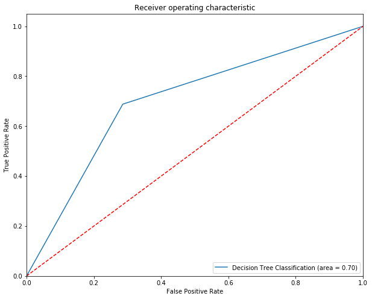

```python
from sklearn.metrics import roc_auc_score
from sklearn.metrics import roc_curve

dtc_roc_auc = roc_auc_score(y_test, dtc.predict(X_test))
fpr, tpr, thresholds = roc_curve(y_test, dtc.predict_proba(X_test)[:,1])
plt.rcParams['figure.figsize'] = [10, 8]
plt.figure()
plt.plot(fpr, tpr, label='Decision Tree Classification (area = %0.2f)' % dtc_roc_auc)
plt.plot([0, 1], [0, 1],'r--')
plt.xlim([0.0, 1.0])
plt.ylim([0.0, 1.05])
plt.xlabel('False Positive Rate')
plt.ylabel('True Positive Rate')
plt.title('Receiver operating characteristic')
plt.legend(loc="lower right")
plt.savefig('Log_ROC')
plt.show()
```

- Not getting good metrics. Let's try other models.

### 3.3 Random Forest Classification

#### 3.3.1 Fitting Random Forest Model

```python
from sklearn.ensemble import RandomForestClassifier

rfc= RandomForestClassifier()
rfc.fit(X_train,y_train)
```

```
RandomForestClassifier(bootstrap=True, class_weight=None, criterion='gini',
            max_depth=None, max_features='auto', max_leaf_nodes=None,
            min_impurity_decrease=0.0, min_impurity_split=None,
            min_samples_leaf=1, min_samples_split=2,
            min_weight_fraction_leaf=0.0, n_estimators=10, n_jobs=1,
            oob_score=False, random_state=None, verbose=0,
            warm_start=False)
```

#### 3.3.2 Checking the accuracy of the model

```python
y_pred = rfc.predict(X_test)
print('Accuracy of logistic regression classifier on test set: {:.2f}'.format(rfc.score(X_test, y_test)))
```

```
Accuracy of logistic regression classifier on test set: 0.77
```

#### 3.3.3 Confusion matrix

```python
from sklearn.metrics import confusion_matrix
confusion_matrix = confusion_matrix(y_test, y_pred)
print(confusion_matrix)
```

```
[[10902  1633]
 [ 3637  6263]]
```

#### 3.3.4 Model metrics

```python
from sklearn.metrics import classification_report
print(classification_report(y_test, y_pred))
```

```
             precision    recall  f1-score   support

          0       0.75      0.87      0.81     12535
          1       0.79      0.63      0.70      9900

avg / total       0.77      0.77      0.76     22435
```

#### 3.3.5 ROC Curve

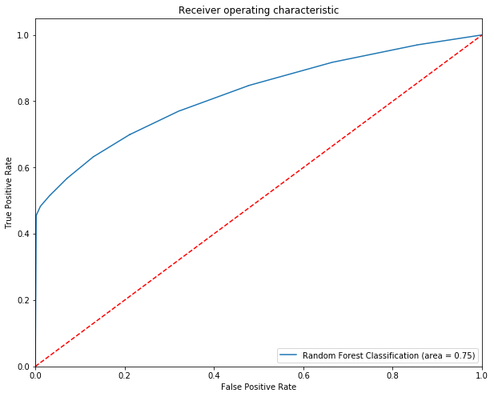

```python
from sklearn.metrics import roc_auc_score
from sklearn.metrics import roc_curve

rfc_roc_auc = roc_auc_score(y_test, rfc.predict(X_test))
fpr, tpr, thresholds = roc_curve(y_test, rfc.predict_proba(X_test)[:,1])
plt.rcParams['figure.figsize'] = [10, 8]
plt.figure()
plt.plot(fpr, tpr, label='Random Forest Classification (area = %0.2f)' % rfc_roc_auc)
plt.plot([0, 1], [0, 1],'r--')
plt.xlim([0.0, 1.0])
plt.ylim([0.0, 1.05])
plt.xlabel('False Positive Rate')
plt.ylabel('True Positive Rate')
plt.title('Receiver operating characteristic')
plt.legend(loc="lower right")
plt.savefig('Log_ROC')
plt.show()
```

### 3.3.6 Feature importance

```python
feature_list = list(df.columns)
importances = list(rfc.feature_importances_)
feature_importances = [(feature, round(importance, 2)) for feature, importance in zip(feature_list, importances)]
```

```python
# Sort the feature importances by most important first
feature_importances = sorted(feature_importances, key = lambda x: x[1], reverse = True)

# Print out the feature and importances
[print('Variable: {:20} Importance: {}'.format(*pair)) for pair in feature_importances]
```

```
Variable: insulin_No           Importance: 0.15
Variable: num_lab_procedures   Importance: 0.13
Variable: num_medications      Importance: 0.12
Variable: time_in_hospital     Importance: 0.08
Variable: insulin_Down         Importance: 0.08
Variable: insulin_Up           Importance: 0.08
Variable: num_procedures       Importance: 0.05
Variable: discharge_disposition_id Importance: 0.04
Variable: number_inpatient     Importance: 0.04
Variable: insulin_Steady       Importance: 0.04
Variable: admission_type_id    Importance: 0.03
Variable: admission_source_id  Importance: 0.03
Variable: number_outpatient    Importance: 0.02
Variable: gender_enc           Importance: 0.02
Variable: number_emergency     Importance: 0.01
Variable: age_(40-70)          Importance: 0.01
Variable: age_(>=70)           Importance: 0.01
Variable: race_AfricanAmerican Importance: 0.01
Variable: race_Caucasian       Importance: 0.01
Variable: readmitted_<30       Importance: 0.01
Variable: readmitted_>30       Importance: 0.01
Variable: readmitted_NO        Importance: 0.01
Variable: age_(0-20)           Importance: 0.0
Variable: age_(20-40)          Importance: 0.0
Variable: race_Asian           Importance: 0.0
Variable: race_Hispanic        Importance: 0.0
Variable: race_Other           Importance: 0.0
```

[output not shown]

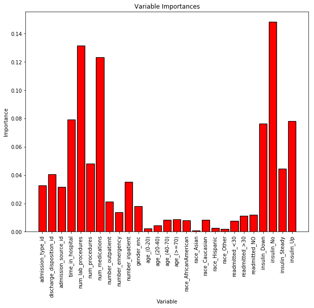

```python
# list of x locations for plotting
x_values = list(range(len(importances)))

# Make a bar chart
plt.bar(x_values, importances, orientation = 'vertical', color = 'r', edgecolor = 'k', linewidth = 1.2)

# Tick labels for x axis
plt.xticks(x_values, feature_list, rotation='vertical')

# Axis labels and title
plt.ylabel('Importance'); plt.xlabel('Variable'); plt.title('Variable Importances');
```

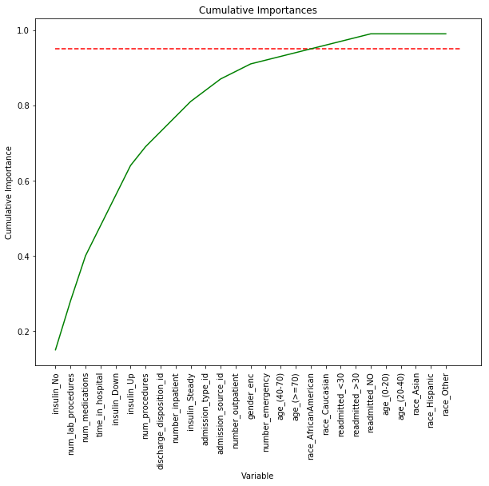

```python
# List of features sorted from most to least important
sorted_importances = [importance[1] for importance in feature_importances]
sorted_features = [importance[0] for importance in feature_importances]

# Cumulative importances
cumulative_importances = np.cumsum(sorted_importances)

# Make a line graph
plt.plot(x_values, cumulative_importances, 'g-')

# Draw line at 95% of importance retained
plt.hlines(y = 0.95, xmin=0, xmax=len(sorted_importances), color = 'r', linestyles = 'dashed')

# Format x ticks and labels
plt.xticks(x_values, sorted_features, rotation = 'vertical')

# Axis labels and title
plt.xlabel('Variable'); plt.ylabel('Cumulative Importance'); plt.title('Cumulative Importances');
```

```python
# Find number of features for cumulative importance of 95%
# Add 1 because Python is zero-indexed
no_f = np.where(cumulative_importances > 0.95)[0][0] + 1
print('Number of features for 95% importance:', no_f)
```

```
Number of features for 95% importance: 18
```

```python
# Extract the names of the most important features
important_feature_names = [feature[0] for feature in feature_importances[0:no_f]]

# Find the columns of the most important features
important_indices = [feature_list.index(feature) for feature in important_feature_names]
```

```python
# Create training and testing sets with only the important features
important_train_features = X_train[:,important_indices]
important_test_features = X_test.iloc[:,important_indices].values

# Sanity check on operations
print('Important train features shape:', important_train_features.shape)
print('Important test features shape:', important_test_features.shape)
```

```
Important train features shape: (58470, 18)
Important test features shape: (22435, 18)
```

```python
#List of selected variables
index = X_test.iloc[:,important_indices].columns
print("Variables selected: \n")
for i in range(0,len(index)):
    print (index[i])
```

```
Variables selected:

insulin_No
num_lab_procedures
num_medications
time_in_hospital
insulin_Down
insulin_Up
num_procedures
discharge_disposition_id
number_inpatient
insulin_Steady
admission_type_id
admission_source_id
number_outpatient
gender_enc
number_emergency
age_(40-70)
age_(>=70)
race_AfricanAmerican
```

#### 3.3.7 Fitting Random Forest Model on selected variables

```python
from sklearn.ensemble import RandomForestClassifier

rfc= RandomForestClassifier()
rfc.fit(important_train_features,y_train)
```

```
RandomForestClassifier(bootstrap=True, class_weight=None, criterion='gini',
            max_depth=None, max_features='auto', max_leaf_nodes=None,
            min_impurity_decrease=0.0, min_impurity_split=None,
            min_samples_leaf=1, min_samples_split=2,
            min_weight_fraction_leaf=0.0, n_estimators=10, n_jobs=1,
            oob_score=False, random_state=None, verbose=0,
            warm_start=False)
```

#### 3.3.8 Checking the accuracy of the model

```python
y_pred = rfc.predict(important_test_features)
print('Accuracy of random forest on test set: {:.2f}'.format(rfc.score(important_test_features, y_test)))
```

```
Accuracy of random forest on test set: 0.76
```

#### 3.3.9 Confusion matrix

```python
from sklearn.metrics import confusion_matrix
confusion_matrix = confusion_matrix(y_test, y_pred)
print(confusion_matrix)
```

```
[[10920  1615]
 [ 3743  6157]]
```

#### 3.3.10 Model metrics

```python
from sklearn.metrics import classification_report
print(classification_report(y_test, y_pred))
```

```
             precision    recall  f1-score   support

          0       0.74      0.87      0.80     12535
          1       0.79      0.62      0.70      9900

avg / total       0.77      0.76      0.76     22435
```

#### 3.3.11 ROC Curve

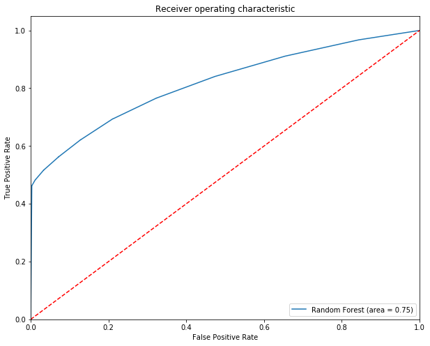

```python
from sklearn.metrics import roc_auc_score
from sklearn.metrics import roc_curve

rfc_roc_auc = roc_auc_score(y_test, rfc.predict(important_test_features))
fpr, tpr, thresholds = roc_curve(y_test, rfc.predict_proba(important_test_features)[:,1])
plt.rcParams['figure.figsize'] = [10, 8]
plt.figure()
plt.plot(fpr, tpr, label='Random Forest (area = %0.2f)' % rfc_roc_auc)
plt.plot([0, 1], [0, 1],'r--')
plt.xlim([0.0, 1.0])
plt.ylim([0.0, 1.05])
plt.xlabel('False Positive Rate')
plt.ylabel('True Positive Rate')
plt.title('Receiver operating characteristic')
plt.legend(loc="lower right")
plt.show()
```

#### 3.3.12 k-fold-cross-validation

```python
from sklearn.model_selection import cross_val_score
accuracies = cross_val_score(estimator=rfc, X=important_train_features,y=y_train, cv=10)
print("Mean accuracy: %0.2f"%accuracies.mean())
print("Standard deviation: %0.2f"%accuracies.std())
```

```
Mean accuracy: 0.78
Standard deviation: 0.05
```

### 3.4 XGBoost Model

### 3.4.1 XGBoost Parameter Tuning:

#### 1- Fill reasonable values for key inputs:

- learning_rate: 0.01
- n_estimators: 100 if the size of your data is high, 1000 if it is medium-low
- max_depth: 3
- subsample: 0.8
- colsample_bytree: 1
- gamma: 1

#### 2- Run model.fit(eval_set, eval_metric) and diagnose the first run, specifically the n_estimators parameter.

#### 3- Optimize max_depth parameter.

- It represents the depth of each tree, which is the maximum number of different features used in each tree. Recommended going from a low max_depth (3 for instance) and then increasing it incrementally by 1, and stopping when there’s no performance gain of increasing it. This will help simplify the model and avoid overfitting.

#### 4- Now play around with the learning rate and the features that avoids overfitting:

- learning_rate: usually between 0.1 and 0.01. If you’re focused on performance and have time in front of you, decrease incrementally the learning rate while increasing the number of trees.
- subsample, which is for each tree the % of rows taken to build the tree. I recommend not taking out too many rows, as performance will drop a lot. Take values from 0.8 to 1.
- colsample_bytree: number of columns used by each tree. In order to avoid some columns to take too much credit for the prediction (think of it like in recommender systems when you recommend the most purchased products and forget about the long tail), take out a good proportion of columns. Values from 0.3 to 0.8 if you have many columns (especially if did one-hot encoding), or 0.8 to 1 if have a few columns.
- gamma: usually misunderstood parameter, it acts as a regularization parameter. Either 0, 1 or 5.

#### References:

- ##### https://www.analyticsvidhya.com/blog/2016/03/complete-guide-parameter-tuning-xgboost-with-codes-python/
- ##### https://towardsdatascience.com/fine-tuning-xgboost-in-python-like-a-boss-b4543ed8b1e
- ##### https://xgboost.readthedocs.io/en/latest/parameter.html

#### 3.4.2 Fitting XGBoost Model

```python
from xgboost import XGBClassifier

xgb = XGBClassifier(silent=True,
                      scale_pos_weight=1,
                      learning_rate=0.1,
                      colsample_bytree = 0.8,
                      subsample = 0.8,
                      objective='binary:logistic',
                      n_estimators=1000,
                      reg_alpha = 0.3,
                      max_depth=5,
                      gamma=0,
                      seed=12)

xgb.fit(important_train_features,y_train)
```

```
XGBClassifier(base_score=0.5, booster='gbtree', colsample_bylevel=1,
       colsample_bytree=0.8, gamma=0, learning_rate=0.1, max_delta_step=0,
       max_depth=5, min_child_weight=1, missing=None, n_estimators=1000,
       n_jobs=1, nthread=None, objective='binary:logistic', random_state=0,
       reg_alpha=0.3, reg_lambda=1, scale_pos_weight=1, seed=12,
       silent=True, subsample=0.8)
```

- Should tune parametes according to best results.

#### 3.4.3 Checking the accuracy of the model

```python
import warnings
warnings.simplefilter("ignore")

y_pred = xgb.predict(important_test_features)
print('Accuracy of XGBoost on test set: {:.2f}'.format(xgb.score(important_test_features, y_test)))
```

```
Accuracy of XGBoost on test set: 0.78
```

#### 3.4.4 Confusion matrix

```python
from sklearn.metrics import confusion_matrix
confusion_matrix = confusion_matrix(y_test, y_pred)
print(confusion_matrix)
```

```
[[11006  1529]
 [ 3436  6464]]
```

#### 3.4.5 Model metrics

```python
from sklearn.metrics import classification_report
print(classification_report(y_test, y_pred))
```

```
             precision    recall  f1-score   support

          0       0.76      0.88      0.82     12535
          1       0.81      0.65      0.72      9900

avg / total       0.78      0.78      0.77     22435
```

#### 3.4.6 ROC Curve

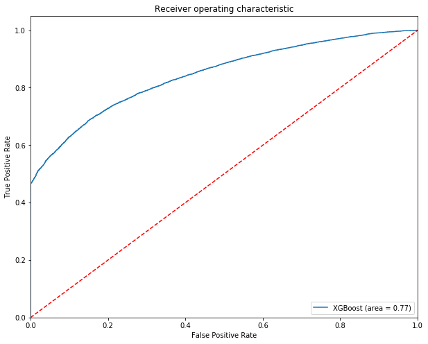

```python
from sklearn.metrics import roc_auc_score
from sklearn.metrics import roc_curve

xgb_roc_auc = roc_auc_score(y_test, xgb.predict(important_test_features))
fpr, tpr, thresholds = roc_curve(y_test, xgb.predict_proba(important_test_features)[:,1])
plt.rcParams['figure.figsize'] = [10, 8]
plt.figure()
plt.plot(fpr, tpr, label='XGBoost (area = %0.2f)' % xgb_roc_auc)
plt.plot([0, 1], [0, 1],'r--')
plt.xlim([0.0, 1.0])
plt.ylim([0.0, 1.05])
plt.xlabel('False Positive Rate')
plt.ylabel('True Positive Rate')
plt.title('Receiver operating characteristic')
plt.legend(loc="lower right")
plt.show()
```

#### 3.4.7 k-fold-cross-validation

```python
import warnings
warnings.simplefilter("ignore")

from sklearn.model_selection import cross_val_score
accuracies = cross_val_score(estimator=xgb, X=important_train_features,y=y_train, cv=10)
print("Mean accuracy: %0.2f"%accuracies.mean())
print("Mean standard deviation: %0.2f"%accuracies.std())
```

```
Mean accuracy: 0.80
Mean standard deviation: 0.06
```

### 3.5 Ensemble Learning: Stacking

Stacking is an ensemble learning technique that uses predictions from multiple models (for example decision tree, knn or svm) to build a new model. This model is used for making predictions on the test set.

Below is a step-wise explanation for a simple stacked ensemble:

- The train set is split into n parts.
- A base model is fitted on 9 parts and predictions are made for the 10th part. This is done for each part of the train set.
- The base model is then fitted on the whole train dataset.
- Using this model, predictions are made on the test set.
- Steps 2 to 4 are repeated for another base model (say knn) resulting in another set of predictions for the train set and test set.
- The predictions from the train set are used as features to build a new model.
- This model is used to make final predictions on the test prediction set.

#### 3.5.1 Function to stack algorithms

```python
def Stacking(model,train,y,test,n_fold):
   folds=StratifiedKFold(n_splits=n_fold,random_state=1)
   test_pred=np.empty((test.shape[0],1),float)
   train_pred=np.empty((0,1),float)
   for train_indices,val_indices in folds.split(train,y):
      x_train,x_val=train[train_indices],train[val_indices]
      y_train,y_val=y[train_indices],y[val_indices]

      model.fit(X=x_train,y=y_train)
      train_pred=np.append(train_pred,model.predict(x_val))
      test_pred=np.append(test_pred,model.predict(test))
      return test_pred.reshape(-1,1),train_pred
```

#### 3.5.2 Fitting Random Forest Model

```python
#Splitting training dataset into 10 subparts
from sklearn.model_selection import StratifiedKFold

model1 = RandomForestClassifier(random_state=1)

test_pred1 ,train_pred1=Stacking(model=model1,n_fold=10, train=important_train_features,test=important_test_features,y=y_train)

train_pred1=pd.DataFrame(train_pred1)
test_pred1=pd.DataFrame(test_pred1)
```

#### 3.5.3 Fitting KNN Classifier Model

```python
from sklearn.neighbors import KNeighborsClassifier

model2 = KNeighborsClassifier()

test_pred2 ,train_pred2=Stacking(model=model2,n_fold=10,train=important_train_features,test=important_test_features,y=y_train)

train_pred2=pd.DataFrame(train_pred2)
test_pred2=pd.DataFrame(test_pred2)
```

#### 3.5.4 Concating the results of both the model

```python
stacked = pd.concat([train_pred1, train_pred2], axis=1)
stacked_test = pd.concat([test_pred1, test_pred2], axis=1)
```

```python
lr = LogisticRegression(random_state=1)
lr.fit(important_train_features,y_train)
```

```
LogisticRegression(C=1.0, class_weight=None, dual=False, fit_intercept=True,
          intercept_scaling=1, max_iter=100, multi_class='ovr', n_jobs=1,
          penalty='l2', random_state=1, solver='liblinear', tol=0.0001,
          verbose=0, warm_start=False)
```

#### 3.5.6 Checking the accuracy of the model

```python
import warnings
warnings.simplefilter("ignore")

y_pred = lr.predict(important_test_features)
print('Accuracy of XGBoost on test set: {:.2f}'.format(lr.score(important_test_features, y_test)))
```

```
Accuracy of XGBoost on test set: 0.78
```

#### 3.5.7 Confusion matrix

```python
from sklearn.metrics import confusion_matrix
confusion_matrix = confusion_matrix(y_test, y_pred)
print(confusion_matrix)
```

```
[[10522  2013]
 [ 2986  6914]]
```

#### 3.5.8 Model metrics

```python
from sklearn.metrics import classification_report
print(classification_report(y_test, y_pred))
```

```
             precision    recall  f1-score   support

          0       0.78      0.84      0.81     12535
          1       0.77      0.70      0.73      9900

avg / total       0.78      0.78      0.78     22435
```

#### 3.5.9 ROC Curve

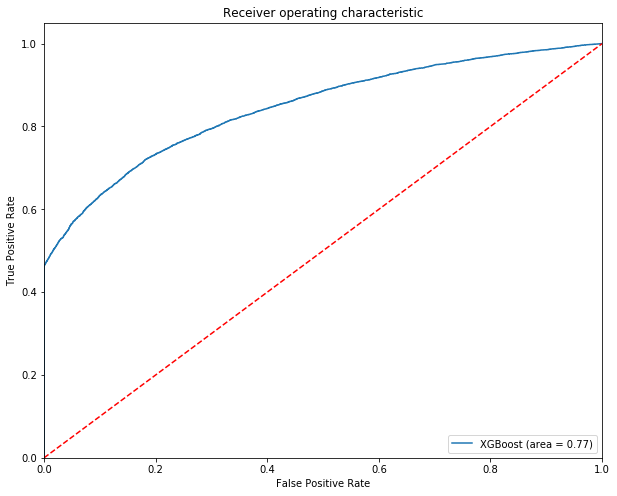

```python
from sklearn.metrics import roc_auc_score
from sklearn.metrics import roc_curve

lr_roc_auc = roc_auc_score(y_test, lr.predict(important_test_features))
fpr, tpr, thresholds = roc_curve(y_test, lr.predict_proba(important_test_features)[:,1])
plt.rcParams['figure.figsize'] = [10, 8]
plt.figure()
plt.plot(fpr, tpr, label='XGBoost (area = %0.2f)' % lr_roc_auc)
plt.plot([0, 1], [0, 1],'r--')
plt.xlim([0.0, 1.0])
plt.ylim([0.0, 1.05])
plt.xlabel('False Positive Rate')
plt.ylabel('True Positive Rate')
plt.title('Receiver operating characteristic')
plt.legend(loc="lower right")
plt.show()
```

#### 3.5.10 k-fold-cross-validation

```python
import warnings
warnings.simplefilter("ignore")

from sklearn.model_selection import cross_val_score
accuracies = cross_val_score(estimator=lr, X=important_train_features,y=y_train, cv=10)
print("Mean accuracy: %0.2f"%accuracies.mean())
print("Mean standard deviation: %0.2f"%accuracies.std())
```

```
Mean accuracy: 0.78
Mean standard deviation: 0.01
```

#### 3.5.11 Showing some *Test data* and corresponding *Predicted values*

```python
predicted = pd.DataFrame(y_pred)
predicted.columns = y
result = y_test
result['Test'] = y_test
result['Predicted'] = predicted
result = result.drop(columns=['change_enc'])
pd.options.display.float_format = "{:.0f}".format
result = result.dropna()
result.head(15)
```

|  | Test | Predicted |
| --- | --- | --- |
| 16476 | 1 | 0 |
| 6734 | 0 | 0 |
| 17510 | 1 | 1 |
| 11221 | 0 | 1 |
| 7910 | 1 | 1 |
| 12436 | 0 | 0 |
| 8049 | 1 | 1 |
| 7344 | 0 | 0 |
| 15098 | 1 | 0 |
| 3095 | 0 | 0 |
| 6006 | 1 | 1 |
| 5981 | 1 | 1 |
| 13718 | 1 | 0 |
| 20716 | 0 | 1 |
| 4406 | 1 | 0 |